# Model Interpretability &amp; Explainability

←Back to the bookChapter 113 · Model Interpretability & Explainability

Chapter 113 · Model Interpretability & Explainability

Model Interpretability & Explainability

Opening the black box of a credit-risk model four ways: permutation importance and partial dependence for the global picture, and SHAP and LIME for why a single applicant was flagged, all library-first with scikit-learn, shap, and lime, and heavily visual.

Statistics, Data Science and AI: A Visual Handbook · John Fisher · 2026

# Model Interpretability & Explainability: opening the black box

A powerful model is often an opaque one: it predicts well but cannot say *why*. For trust, debugging, fairness, and regulation, we need to open it up. This notebook explains a credit-risk model four ways: **permutation importance** and **partial dependence** (global, how the model behaves overall) and **SHAP** and **LIME** (local, why it made *this* prediction). Library-first with `scikit-learn`, `shap`, and `lime`.

```python
import numpy as np, pandas as pd, matplotlib.pyplot as plt
import seaborn as sns   # seaborn = high-level statistical plots (heatmaps, pairplots, count/bar plots)
from matplotlib.colors import ListedColormap
EM="#4338ca"; DEEP="#3730a3"; LIGHT="#c7d2fe"; INK="#1a2138"; GRID="#e6e9f2"; RED="#ef4444"; AMBER="#d97706"; GREEN="#059669"; BLUE="#2563eb"; PUR="#9333ea"; GREY="#94a3b8"; SLATE="#475569"; ORG="#4338ca"; CYAN="#0891b2"
plt.rcParams.update({"figure.facecolor":"white","axes.facecolor":"white","figure.dpi":110,"font.size":11,
   "axes.edgecolor":GRID,"axes.grid":True,"grid.color":GRID,"axes.axisbelow":True,"axes.spines.top":False,
   "axes.spines.right":False,"axes.titlesize":12,"axes.titleweight":"bold","legend.frameon":False})
sns.set_style("whitegrid")
BASE="https://raw.githubusercontent.com/johnfisher-ai/Statistics-Data-Science-AI-Visual-Book/main/data/"
```

```python
import warnings; warnings.filterwarnings('ignore')
from sklearn.model_selection import train_test_split
from sklearn.ensemble import GradientBoostingClassifier
from sklearn.inspection import permutation_importance, PartialDependenceDisplay
import shap, lime, lime.lime_tabular
pd.set_option('display.max_columns', 30)
```

DEMO 1 · A GOOD MODEL, BUT WHY?

Accuracy is not an explanation

Train the model we will interrogate.

```python
try: df = pd.read_excel('../../data/ch113_credit.xlsx', sheet_name='Data')
except FileNotFoundError: df = pd.read_excel(BASE + 'ch113_credit.xlsx', sheet_name='Data')
feat = ['credit_score','debt_to_income','income_k','loan_amount_k','num_late_payments','employment_years']
X, y = df[feat], df['default']
X_train, X_test, y_train, y_test = train_test_split(X, y, test_size=0.25, random_state=0, stratify=y)
model = GradientBoostingClassifier(random_state=0).fit(X_train, y_train)
print(f'gradient-boosting test accuracy = {model.score(X_test, y_test):.3f}')
print('...but if the bank denies a loan, it must explain WHY. That is what this chapter delivers.')
```

```
gradient-boosting test accuracy = 0.710
...but if the bank denies a loan, it must explain WHY. That is what this chapter delivers.
```

**Two kinds of explanation.** A gradient-boosting model predicts default well, yet it is a **black box**, hundreds of trees give no single readable rule. Interpretability tools come in two flavors. **Global** explanations describe how the model behaves *overall* (which features matter, and how). **Local** explanations justify *one specific prediction* (why was this applicant denied?). We need both, and we will build both.

DEMO 2 · GLOBAL: PERMUTATION IMPORTANCE

Which features drive the model?

Shuffle a feature and watch accuracy drop.

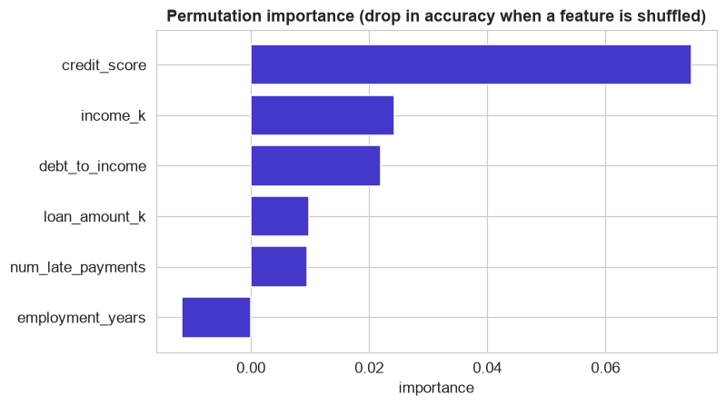

```
credit_score         0.0745
income_k             0.0242
debt_to_income       0.0220
loan_amount_k        0.0097
num_late_payments    0.0095
employment_years    -0.0118
```

```python
r = permutation_importance(model, X_test, y_test, n_repeats=20, random_state=0)
imp = pd.Series(r.importances_mean, index=feat).sort_values()
fig, ax = plt.subplots(figsize=(7.4,4.2))
ax.barh(imp.index, imp.values, color=EM)
ax.set(title='Permutation importance (drop in accuracy when a feature is shuffled)', xlabel='importance'); plt.tight_layout(); plt.show()
print(imp.sort_values(ascending=False).round(4).to_string())
```

DEMO 3 · GLOBAL: PARTIAL DEPENDENCE

How does a feature change the prediction?

Importance says which; partial dependence says how.

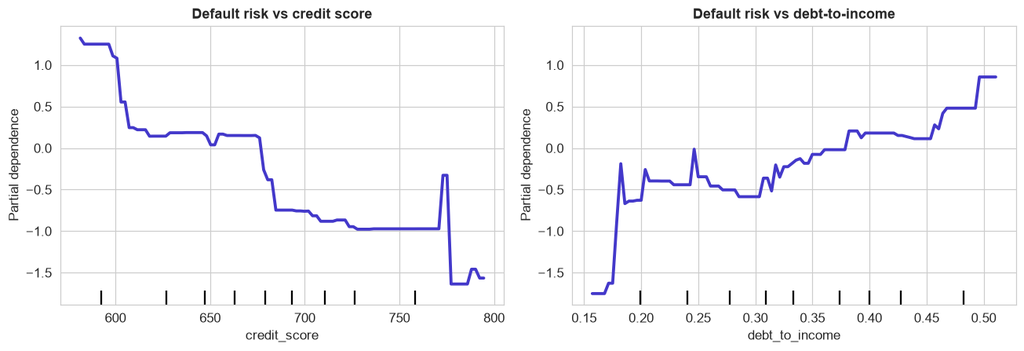

```python
fig, ax = plt.subplots(1, 2, figsize=(12,4.2))
PartialDependenceDisplay.from_estimator(model, X_test.astype(float), ['credit_score','debt_to_income'], ax=ax, line_kw={'color': EM, 'linewidth':2.5})
ax[0].set_title('Default risk vs credit score'); ax[1].set_title('Default risk vs debt-to-income')
plt.tight_layout(); plt.show()
```

DEMO 4 · LOCAL & GLOBAL: SHAP

Every prediction, decomposed into feature contributions

SHAP unifies global and local with one consistent measure.

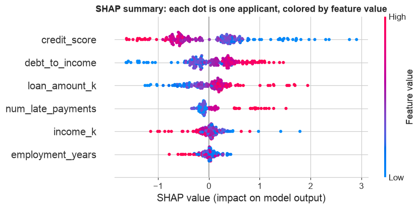

```python
explainer = shap.TreeExplainer(model)
shap_values = explainer(X_test)
plt.figure()
shap.plots.beeswarm(shap_values, show=False, max_display=6)
plt.title('SHAP summary: each dot is one applicant, colored by feature value'); plt.tight_layout(); plt.show()
```

**What SHAP does.** **SHAP** (SHapley Additive exPlanations) borrows a fair-payout idea from game theory: it splits each prediction into an additive contribution from every feature, in a way that is mathematically consistent. The **beeswarm** plot is a global view built from local pieces: each dot is one applicant's SHAP value for a feature, and the **color is the feature's value** (blue low, red high). You can read both magnitude *and* direction at once, high debt-to-income (red) pushes strongly **toward** default (right), while a high credit score (red) pushes **away** from it (left). It is the richest single summary an interpretability tool offers.

DEMO 5 · SHAP FOR ONE DECISION

Why was THIS applicant flagged?

The local explanation a regulator can read.

```
applicant profile:
credit_score         551.000
debt_to_income         0.682
income_k              43.000
loan_amount_k         42.600
num_late_payments      0.000
employment_years       4.300
predicted default probability = 0.91
```

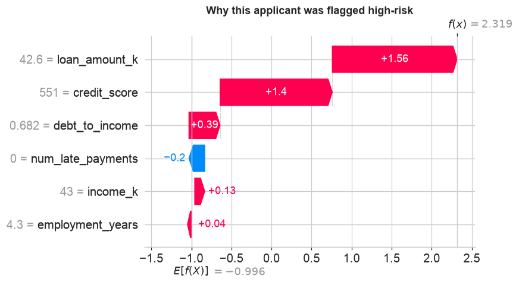

```python
i = int(np.argmax(model.predict_proba(X_test)[:,1]))     # the highest-risk applicant
print('applicant profile:'); print(X_test.iloc[i].to_string())
print(f'predicted default probability = {model.predict_proba(X_test.iloc[[i]])[0,1]:.2f}')
plt.figure()
shap.plots.waterfall(shap_values[i], show=False, max_display=6)
plt.title('Why this applicant was flagged high-risk'); plt.tight_layout(); plt.show()
```

**The local story.** The **waterfall** plot explains a single prediction: it starts at the average prediction and adds each feature's push, up (red, toward default) or down (blue, away), until it reaches this applicant's score. For our highest-risk applicant you can see exactly which factors drove the decision, a large loan, an elevated debt-to-income ratio, and a low credit score piling on risk, only partly offset by the rest. **This** is the artifact you hand a customer or an auditor: not a bare denial, but a ranked, quantitative reason.

DEMO 6 · LIME: A LOCAL LINEAR SURROGATE

A second opinion on the same decision

LIME fits a simple model near one point.

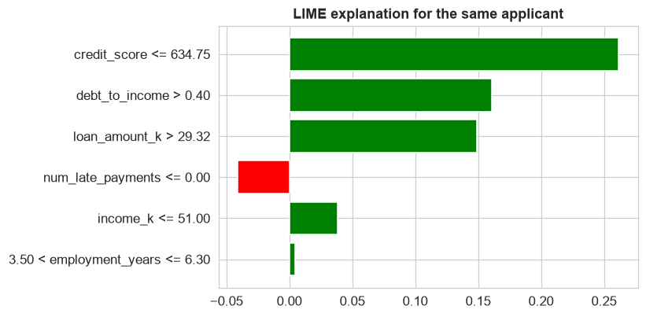

```
LIME feature contributions:
  credit_score <= 634.75: +0.262
  debt_to_income > 0.40: +0.161
  loan_amount_k > 29.32: +0.149
  num_late_payments <= 0.00: -0.041
  income_k <= 51.00: +0.039
  3.50 < employment_years <= 6.30: +0.005
```

```
[None, None, None, None, None, None]
```

```python
lt = lime.lime_tabular.LimeTabularExplainer(X_train.values, feature_names=feat,
        class_names=['repaid','default'], mode='classification', random_state=0)
exp = lt.explain_instance(X_test.values[i], model.predict_proba, num_features=6)
fig = exp.as_pyplot_figure(); fig.set_size_inches(7.6,3.8)
plt.title('LIME explanation for the same applicant'); plt.tight_layout(); plt.show()
print('LIME feature contributions:'); [print(f'  {f}: {w:+.3f}') for f,w in exp.as_list()]
```

**How LIME differs.** **LIME** (Local Interpretable Model-agnostic Explanations) takes a different route to the same goal: it probes the black box with many small perturbations *around one applicant*, then fits a simple, readable **linear model** to that neighborhood. The bars show each feature pushing the local prediction toward default (positive) or repayment (negative). LIME is fully model-agnostic (it never looks inside the model, only its predictions) and works on tabular data, text, and images alike. When SHAP and LIME **surface the same set of drivers**, as they do here (credit score, loan size, and debt-to-income), you can trust the explanation.

## Interpretability, in one view

- **Global, which features matter**: permutation importance (model-agnostic, more reliable than impurity importances).
- **Global, how a feature acts**: partial dependence (average effect) and ICE (per-instance).
- **Local + global, one consistent measure**: **SHAP**, additive feature contributions per prediction; beeswarm for the whole model, waterfall for one decision.
- **Local, model-agnostic**: **LIME**, a simple linear model fit around a single prediction.
- Interpretability is not optional: it is the foundation of **trust, debugging, fairness, and regulatory compliance** in deployed models.

Statistics, Data Science and AI: A Visual Handbook · © 2026 John Fisher

←Back to the bookChapter 113 · Model Interpretability & Explainability